# Trust but Verify: AI Models for Coding Political Content in Social Media

Inmaculada Gutierrez

2026-09-09

## Load needed libraries

```r
library(openxlsx)
library(readr)
library(readxl)
library(dplyr)
library(irr)
library(bookdown)
library(scales)
library(RColorBrewer)
library(ggplot2)
library(caret)
library(stringr)
library(stringi)
library(viridis)
library(tibble)
library(writexl)
library(corrplot)
library(Hmisc)
library(tidyr)
```

#Please read the README first: The complete workflow, including the data processing procedure, the files involved, and the steps required to reproduce the analysis, is described in this README. We kindly recommend reading this document before running the code or examining the individual files, as it provides the necessary context and guidance for following the workflow correctly.

# Pilot analysis

We conducted a pilot study to analyze two critical design choices (beyond selecting the large language model (LLM)) that would be essential for any subsequent analysis:

1. How to formulate prompts.
2. How to convert BART’s scoring estimates into binary (or ordinal) classifications suitable for comparison with human coding.

We created synthetic posts simulating content from X/Twitter using ChatGPT-4, prompted with iterative instructions to generate posts reflecting diverse perspectives on each issue.

This method yielded 777 synthetic posts, roughly balanced across the eight issues. Each post was labeled with a 1 for at least one relevant issue and typically received a 0 for the remaining seven, except in incidental cases.

Two expert coders have classified each sentence into 0/1.

If one prefers to work interactively with an R script, all the information and processes developed in this file regarding the Pilot analysis can be reproduced in the script `PilotStudy.R`.

## Load the dataset

The input file containing the pilot dataset is *Pilot_Data.xlsx*, located in the *Data* folder.

```r
pilot_data <- read_excel("Data/Pilot_Data.xlsx",sheet='Complete Data All Issues')
#head(pilot_data) #Uncomment to view the data header.
```

Initially, *pilot_data* has 777 observations and 26 variables: each text is assigned an ID, along with the sentence itself (*sequence*), and for each of the 8 topics, three classification columns: one ending in *ConsensusTruth*, which represents the consensus between expert 1 and expert 2, one ending in *Code1*, and another ending in *Code2*.

For example, for immigration we have *Imm_ConsensusTruth*, *Imm_Code1* and *Imm_Code2*.

## Classification process

The first step is to obtain the classifications for each text in the pilot dataset, considering four hypotheses:

- *h1*: “This text is about []”
- *h2*: “This text focuses on []”
- *h3*: “The main subject of this text is []”
- *h4*: “This text is related to []”, and the eight previously defined issues (*l1–l8*).

To do so, we apply the `textZeroShot` function of the `text` library combined with two loops to consider all the *h1-h4* and all the issues, labeled as *l1-l8*.

Since the pilot dataset was synthetically generated, there is no need to perform any text-cleaning process in this case.

After the classification process, *pilot_data* will contain 58 variables: the initial 26, plus 32 classifications for each *hi_lj* combination (referring to the *i*-th prompt and the *j*-th topic).

```r
labels= c("Immigration", "Health Care", "Foreign Affairs",'Elections',"Civil Rights","Culture","Trump","Climate Change")
hypothesis=c("This text is about {}.", "This text focuses on {}.", "The main subject of this text is {}", "This text is related to {}")
```

- `pilot_data`: a dataframe containing the 777 texts to be classified.
- `labels`: a vector comprising the 8 issues to be considered.
- `hypothesis`: a vector encompassing the 4 working prompts.

The classification results are appended to the `pilot_data` dataframe, resulting in 32 new columns corresponding to each *hi_lj* combination, where *hi* denotes the hypothesis *i* and *lj* represents the label *j*.

This approach facilitates zero-shot classification using the BART model, enabling the evaluation of the relationship between texts and formulated hypotheses without additional training.

This part of the process, explained below, is provided in scripts separate from the rest of the analysis, as the execution time is high and may slow down or cause memory issues during the compilation of the Markdown document.

## Zero-Shot Classification

The following function implements the Zero-Shot Classification (ZSC) procedure using the `facebook/bart-large-mnli` model. For each combination of hypothesis and candidate label, the function applies the classification model to all text sequences and stores the resulting scores in a new column.

> **Important:** Due to the computational complexity and computational cost of the ZSC procedure, we recommend executing the classification **modularly**, rather than running the complete process in a single execution. In particular, the procedure can be divided by **hypothesis, topic/label, or batches of texts**, depending on the available computational resources. This modular approach makes the process more manageable and allows the complete classification to be distributed across different sessions or computers.

The function below is provided for reference and is **not intended to be executed automatically** when rendering this Markdown file.

```r
ZSC <- function(pilot_data, labels, hypothesis) {
  for (h in seq_along(hypothesis)) {
    for (l in seq_along(labels)) {
      # Name of the variable for each classification
      variable_name <- paste0("h", h, "_l", l)

      # Perform zero-shot classification for each combination
      result <- textZeroShot(
        sequences = pilot_data$sequence,
        candidate_labels = labels[l],
        hypothesis_template = hypothesis[h],
        multi_label = FALSE,
        model = "facebook/bart-large-mnli",
        device = "cpu",
        tokenizer_parallelism = FALSE,
        logging_level = "error",
        return_incorrect_results = FALSE,
        set_seed = 1001L
      )

      # Store results in new column
      pilot_data[[variable_name]] <- result$scores_x_1
    }
  }

  return(pilot_data)
}

# Uncomment to apply ZSC. Warning: this may take a considerable amount of time.
# pilot_data = ZSC(pilot_data, labels, hypothesis)

# Uncomment to save the pilot_data list as an .xlsx file.
# write.xlsx(pilot_data, file = "Data/Pilot_classification.xlsx")
```

## Analysis of the metrics

The input for this section is the `pilot_data` dataframe created in the previous section *Pilot analysis/Classification process*. Excel file *Pilot_classification.xlsx*, sheet *LLM* for the zero-shot LLM models and sheet *LLaMA* for the results of the corresponding model, located in the *Data* folder can be used instead.

```r
# Path to the Excel file
excel_file <- "Data/Pilot_classification.xlsx"
LLM <- read_excel(excel_file,sheet='LLM')%>%select(ID,sequence, h1_l1, h1_l2, h1_l3, h1_l4, h1_l5, h1_l6, h1_l7, h1_l8, h2_l1, h2_l2, h2_l3, h2_l4, h2_l5, h2_l6, h2_l7, h2_l8, h3_l1, h3_l2, h3_l3, h3_l4, h3_l5, h3_l6,  h3_l7, h3_l8, h4_l1, h4_l2, h4_l3, h4_l4, h4_l5, h4_l6, h4_l7, h4_l8)

LLaMA <- read_excel(excel_file,sheet='LLaMA')

human <- read_excel(excel_file,sheet='LLM')%>%
  select(ID,sequence, Imm_ConsensusTruth, Imm_Code1, Imm_Code2, HealthCare_ConsensusTruth, HealthCare_Code1, HealthCare_Code2, ForAff_ConsensusTruth, ForAff_Code1, ForAff_Code2, Elections_ConsensusTruth, Elections_Code1, Elections_Code2, CivRights_ConsensusTruth, CivRights_Code1, CivRights_Code2, Culture_ConsensusTruth, Culture_Code1, Culture_Code2, Trump_ConsensusTruth, Trump_Code1, Trump_Code2, Env_ConsensusTruth, Env_Code1, Env_Code2)
```

Zero-shot models scores have to be binarized in order to compare them agains human classifications. A grid of binarization thresholds between 0.3 and 0.7 was employed to assess the impact of different threshold values on the comparison metrics.

```r
thresholds <- c(0.3, 0.35, 0.4, 0.45, 0.5, 0.55, 0.6, 0.65, 0.7)

# Function to apply threshold
apply_threshold <- function(value, threshold) {
  ifelse(value >= threshold, 1, 0)
}
# Columns to apply the threshold. It considers only the relevant columns that include classifications.
classifications <- setdiff(colnames(LLM), c("ID", "sequence"))
classifications_LLaMA <- setdiff(colnames(LLaMA), c("ID", "sequence"))
# Initialize a list to store the DataFrames
threshold_dataframes <- list()
for (threshold in thresholds) {
  # Generate DataFrame name dynamically (ensure integer conversion)
  df_name <- sprintf("LLM_%02d", as.integer(threshold * 100))

  # Create a copy of the DataFrame and apply the threshold
  LLM_copy <- LLM
  LLM_copy[classifications] <- lapply(LLM_copy[classifications], apply_threshold, threshold)
  LLM_copy$TH <- threshold

  # Store in the list
  threshold_dataframes[[df_name]] <- LLM_copy
}
# Uncomment following lines to save different binarizations as Excel
 wb <- createWorkbook()
 for (name in names(threshold_dataframes)) {
 addWorksheet(wb, name)
 writeData(wb, name, threshold_dataframes[[name]])}
 saveWorkbook(wb, "Data/binarizations_LLM.xlsx", overwrite = TRUE)
```

Same binarization process for LLaMA results

```r
threshold_LLaMA <- list()
for (threshold in thresholds) {
  # Generate DataFrame name dynamically (ensure integer conversion)
  df_name <- sprintf("LLaMA_%02d", as.integer(threshold * 100))

  # Create a copy of the DataFrame and apply the threshold
 LLaMA_copy <-LLaMA
 LLaMA_copy[classifications_LLaMA] <- lapply(LLaMA_copy[classifications_LLaMA], apply_threshold, threshold)
 LLaMA_copy$TH <- threshold

  # Store in the list
  threshold_LLaMA[[df_name]] <-LLaMA_copy
}

# Save different binarizations as Excel
wb <- createWorkbook()
for (name in names(threshold_LLaMA)) {
  addWorksheet(wb, name)
  writeData(wb, name, threshold_LLaMA[[name]])}
  saveWorkbook(wb, "Data/binarizations_LLaMA.xlsx", overwrite = TRUE)
```

Next, we organize the variables in order to proceed with the comparison between the binarized Zero-shot/LLaMA classifications and those provided by the human coders.

```r
# Define the column groups for humans
cols_data2 <- c('l1', 'l2', 'l3', 'l4', 'l5', 'l6', 'l7', 'l8')
cols_data1 <- c('h1_l1', 'h1_l2', 'h1_l3', 'h1_l4', 'h1_l5', 'h1_l6', 'h1_l7', 'h1_l8', 'h2_l1', 'h2_l2', 'h2_l3', 'h2_l4', 'h2_l5', 'h2_l6', 'h2_l7', 'h2_l8', 'h3_l1', 'h3_l2', 'h3_l3', 'h3_l4', 'h3_l5', 'h3_l6', 'h3_l7', 'h3_l8', 'h4_l1', 'h4_l2', 'h4_l3', 'h4_l4', 'h4_l5', 'h4_l6', 'h4_l7', 'h4_l8')
cols_LLaMA <- c("Immigration","Health Care","Foreign Affairs","Elections","Civil Rights","Culture","Trump","Climate Change" )
# Make a copy of 'human' without 'ID' and 'sequence'
human_copy <- human %>% select('Imm_ConsensusTruth','HealthCare_ConsensusTruth','ForAff_ConsensusTruth','Elections_ConsensusTruth','CivRights_ConsensusTruth','Culture_ConsensusTruth','Trump_ConsensusTruth','Env_ConsensusTruth')
human2 <- subset(human, select=-c(ID,sequence))
# Rename columns
colnames(human_copy) <- cols_data2
```

Create an empty results DataFrame where we store, for each threshold and each hypothesis–issue combination, different goodness-of-fit metrics: False Positives (*FP*), False Negatives (*FN*), True Positives (*TP*), True Negatives (*TN*), threshold value (*TH*), *recall*, *precision*, *accuracy*, *f1*, Cohen’s Kappa between human consensus and BART (*kappa*), Fleiss’s kappa between human Code 1, Code 2 and BART (*kappa_fleiss*), Cohen’s Kappa between human Code 1 and Code 2 (*kappa_C1C2*), Cohen’s Kappa between human Code 1 and BART (*kappa_C1BART*), Cohen’s Kappa between human Code 2 and BART (*kappa_C2BART*).

For the calculation of recall, precision, accuracy, and F1, the consensus value of the human coders is considered as the ground truth.

```r
results_df <- data.frame(Issue=character(), FP=integer(), FN=integer(), TP=integer(), TN=integer(), TH=numeric(), recall=numeric(), precision=numeric(), accuracy=numeric(), f1 = numeric(),kappa=numeric(), topic=character(),hypothesis=character(), kappa_fleiss=numeric(), kappa_C1C2=numeric(),kappa_C1BART=numeric(), kappa_C2BART=numeric(), stringsAsFactors = FALSE)
```

Next, through the use of loops, all possible binarizations are iterated over, and the previously defined metrics are computed accordingly.

```r
for(df_name in names(threshold_dataframes)){
  LLM_copy <- threshold_dataframes[[df_name]]
  TH <- unique(LLM_copy$TH)
  for (i in 0:3) {  # 4 hypotheses
    for (k in 1:8) {  # 8 labels/topics per hypothesis
      c <- i * 8 + k  # Adjust index accordingly
      # Define true/predicted labels
      y_true <- human_copy[[cols_data2[k]]]
      y_pred <- LLM_copy[[classifications[c]]]
      selected_columns <- human2[, c(3*k-1, 3*k)]
      #first column in selected_columns is BART classification
      #second column in selected_columns is Coder1 classification
      #third column in selected_columns is Coder2 classification
      selected_columns <- cbind(y_pred, selected_columns)
      # Compute confusion matrix
      cm <- table(
       factor(y_true, levels = c(0, 1)),
       factor(y_pred, levels = c(0, 1)))
      FP <- cm[1,2]
      FN <- cm[2,1]
      TP <- cm[2,2]
      TN <- cm[1,1]
      # Compute classification metrics
      precision <- ifelse((TP+FP) != 0, TP / (TP+FP), 0)
      recall <- ifelse((TP+FN) != 0, TP / (TP+FN), 0)
      accuracy <- ifelse((TP+TN+FP+FN) != 0, (TP+TN) / (TP+TN +FP+FN), 0)
      f1_score <- ifelse((precision+recall) != 0, (2*precision*recall)/(precision+recall), 0)
      # Compute Cohen's Kappa
      kappa_stat <- kappa2(data.frame(y_true, y_pred))$value
      kappa_C1C2 <- kappa2(data.frame(selected_columns[,2],selected_columns[,3]))$value
      kappa_C1BART <- kappa2(data.frame(selected_columns[,2], y_pred))$value
      kappa_C2BART <- kappa2(data.frame(selected_columns[,3], y_pred))$value
      kappa_fleiss=kappam.fleiss(as.matrix(selected_columns))$value
      # Extract 'hypothesis' from 'Issue' column (only numbers, removing 'h')
      hypothesis <- as.character(str_extract(classifications[c], "(?<=h)\\d+"))
      # Extract 'topic' from 'Issue' column (only numbers, removing 'l')
      topic <- as.character(str_extract(classifications[c], "(?<=l)\\d+"))
      # Create a new row with the results
      new_row <- data.frame(Issue = classifications[c], FP = FP, FN = FN, TP = TP, TN = TN, TH = TH, recall = recall, precision = precision, accuracy = accuracy, f1 = f1_score, kappa=kappa_stat,topic=topic, hypothesis=hypothesis, kappa_fleiss=kappa_fleiss,kappa_C1C2=kappa_C1C2, kappa_C1BART=kappa_C1BART,kappa_C2BART=kappa_C2BART)
      # Append new row to results DataFrame
      results_df <- bind_rows(results_df, new_row)
      # Define class labels
      classes <- c("Class 0", "Class 1")
      # Create heatmap of the confusion matrix
      cm_matrix <- matrix(c(TN, FP, FN, TP), nrow = 2, byrow = TRUE)
      cm_df <- as.data.frame(as.table(cm_matrix))
      cm_plot<-ggplot(cm_df, aes(Var2, Var1, fill = Freq))+geom_tile(color = "white")+scale_fill_gradientn(colors = c("LightYellow", "yellow", "orange", "red"), guide = "none")+geom_text(aes(label = Freq), color = "black", size =  5) + theme_minimal() + labs(title = paste("Evolution of Metrics for Prompt", hypothesis, "and Topic", topic),x = "Predicted Labels", y = "True Labels") +scale_x_discrete(labels = classes) +scale_y_discrete(labels = classes) + theme(axis.text.x = element_text(angle = 45, hjust = 1),plot.background = element_rect(fill = "white", color = NA))  # Ensure white background
      # Uncomment to print the plot
      # print(cm_plot)
      # Uncomment to save the figure
       #filename <- sprintf("Results/Pilot/Confusion Matrices/TH=%s_Confusion_Matrix_%s.png", TH, gsub("[ \n.]", "_",classifications[c]))
      #ggsave(filename=filename,plot=cm_plot,dpi=300,width=5,height=5,bg="white")
    }}}
# Uncomment to save ´results_df´as a XLSX file.
    write_xlsx(results_df, "Results/Pilot/LLM/results_pilot_LLM.xlsx")
results_pilot_LLM = results_df
```

The metrics obtained for the different thresholds and issues are located in the file `results_pilot_LLM.xlsx`, within the `Results/Pilot/LLM` folder.

Then, we apply the same metric calculation procedure to the LLaMA classifications in the pilot dataset.

```r
## LLaMA VS Human
results_pilot_LLaMA <- data.frame(Issue = character(), FP = integer(), FN = integer(), TP = integer(),TN = integer(), TH = numeric(), recall = numeric(), precision = numeric(), accuracy = numeric(), f1 = numeric(),kappa=numeric(),
topic=character(),hypothesis=character(),kappa_fleiss=numeric(), kappa_C1C2=numeric(),kappa_C1LLaMA=numeric(), kappa_C2LLaMA=numeric(),stringsAsFactors = FALSE)

for(df_name in names(threshold_LLaMA)){
 LLaMA_copy <- threshold_LLaMA[[df_name]]
  TH <- unique(LLaMA_copy$TH)
    for (k in 1:8) {  # 8 labels/topics per hypothesis
     # c <-  k  # Adjust index accordingly
      # Define true/predicted labels
      y_true <- human_copy[[cols_data2[k]]]
      y_pred <-LLaMA_copy[[cols_LLaMA[k]]]

      selected_columns <- human2[, c(3*k-1, 3*k)]
      # selected_columns <- human2[, seq(2, ncol(human2), by = 2)]
      selected_columns <- cbind(y_pred, selected_columns)
      # Compute confusion matrix
      cm <- table(y_true, y_pred)
      FP <- cm[1,2]
      FN <- cm[2,1]
      TP <- cm[2,2]
      TN <- cm[1,1]
      # Compute classification metrics
      precision <- ifelse((TP + FP) != 0, TP / (TP + FP), 0)
      recall <- ifelse((TP + FN) != 0, TP / (TP + FN), 0)
      accuracy <- ifelse((TP + TN + FP + FN) != 0, (TP + TN) / (TP + TN + FP + FN), 0)
      f1_score <- ifelse((precision + recall) != 0, (2 * precision * recall) / (precision + recall), 0)
      # Compute Cohen's Kappa
      kappa_stat <- kappa2(data.frame(y_true, y_pred))$value
      kappa_C1C2 <- kappa2(data.frame(selected_columns[,2],selected_columns[,3]))$value
      kappa_C1LLaMA <- kappa2(data.frame(selected_columns[,2], y_pred))$value
      kappa_C2LLaMA <- kappa2(data.frame(selected_columns[,3], y_pred))$value
      kappa_fleiss=kappam.fleiss(as.matrix(selected_columns))$value
      # Extract 'hypothesis' from 'Issue' column (only numbers, removing 'h')
      hypothesis <- as.character(str_extract(cols_data1[k], "(?<=h)\\d+"))
      # Extract 'topic' from 'Issue' column (only numbers, removing 'l')
      topic <- as.character(str_extract(cols_data1[k], "(?<=l)\\d+"))

      # Create a new row with the results
      new_row <- data.frame(
        Issue = cols_data2[k], FP = FP, FN = FN, TP = TP, TN = TN, TH = TH,
        recall = recall, precision = precision, accuracy = accuracy,
        f1 = f1_score, kappa=kappa_stat,topic=topic, hypothesis=hypothesis, kappa_fleiss=kappa_fleiss,kappa_C1C2=kappa_C1C2, kappa_C1LLaMA=kappa_C1LLaMA,kappa_C2LLaMA=kappa_C2LLaMA
      )

      # Append new row to results DataFrame
      results_pilot_LLaMA <- bind_rows(results_pilot_LLaMA, new_row)
       }
  }
# Uncomment to save ´results_df´as a XLSX file.
 write_xlsx(results_pilot_LLaMA, "Results/Pilot/LLaMA/results_pilot_LLaMA.xlsx")
```

The metrics obtained for the different thresholds and issues are located in the file `results_pilot_LLaMA.xlsx`, within the `Results/Pilot/LLaMA` folder.

## Metrics representation

Once all the metrics are calculated, they are represented in different contexts to facilitate their analysis and enable a decision to be made regarding the threshold.

```r
colors <- c("Recall" = "#FFD700", "Precision" = "#66CD00", "Accuracy" = "#FF3030", "F1" = "#00BFFF", "Human Consensus-LLM 2 codes kappa"="#D15FEE", "Humans-LLM 3 codes kappa"="#FFC0CB", "Code 1-Code 2 kappa"="#C1CDC1", "Code 1-LLM kappa"="#8B0000", "Code 2-LLM kappa"="#27408B","Human Consensus-LLaMA 2 codes kappa"="#D15FEE", "Humans-LLaMA 3 codes kappa"="#FFC0CB", "Code 1-Code 2 kappa"="#C1CDC1", "Code 1-LLaMA kappa"="#8B0000", "Code 2-LLaMA kappa"="#27408B")


# Obtain unique combinations of hypotheses and topics for LLM
unique_combinations_LLM <- unique(results_pilot_LLM[, c("hypothesis", "topic")])
labels_LLM= c("Immigration", "Health Care", "Foreign Affairs",'Elections',"Civil Rights","Culture","Trump","Climate Change")
hypothesis_LLM=c("This text is about {}.", "This text focuses on {}.", "The main subject of this text is {}", "This text is related to {}")
```

#### Plot recall, accuracy, precision and f1 across the threshold for LLM

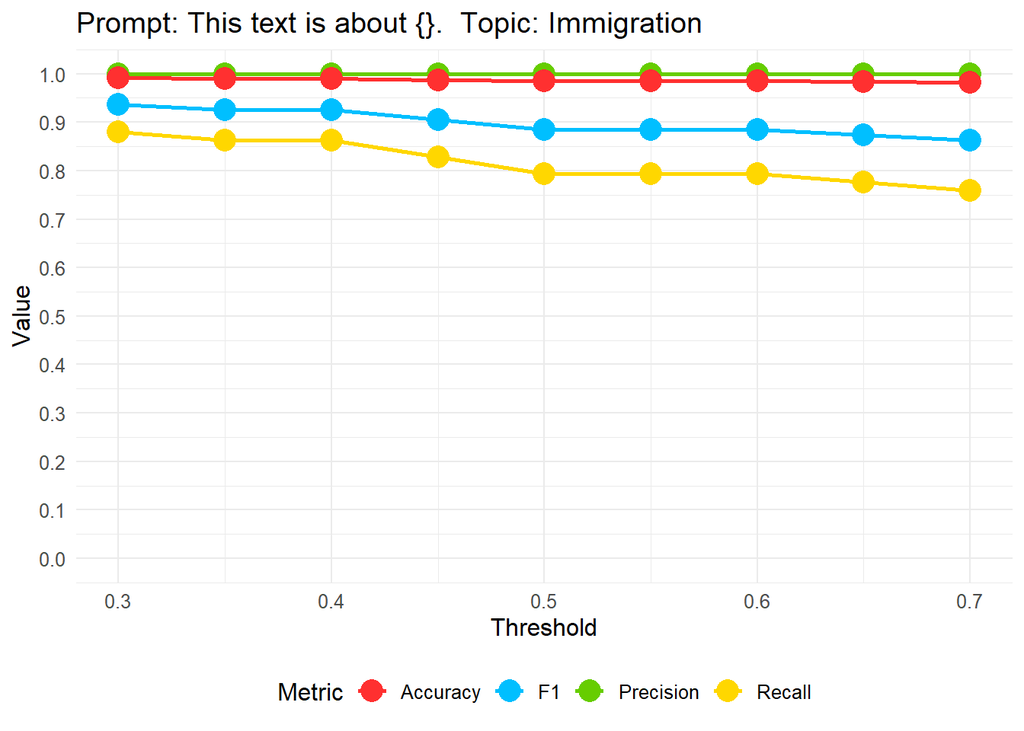

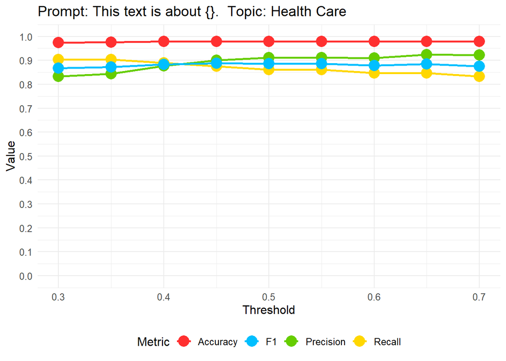

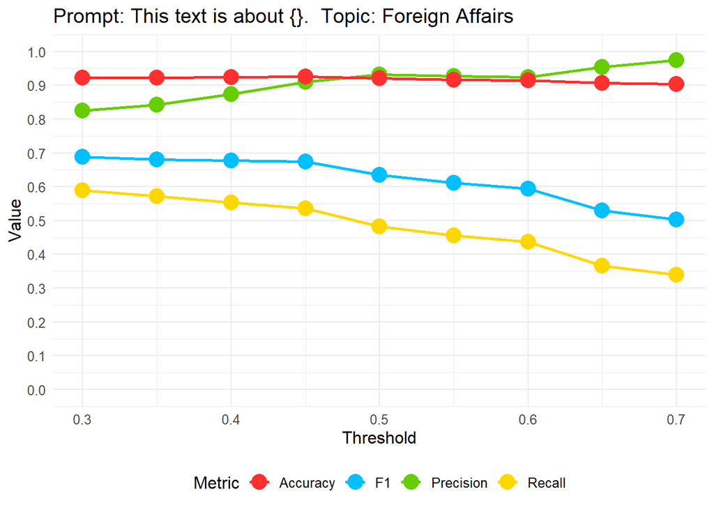

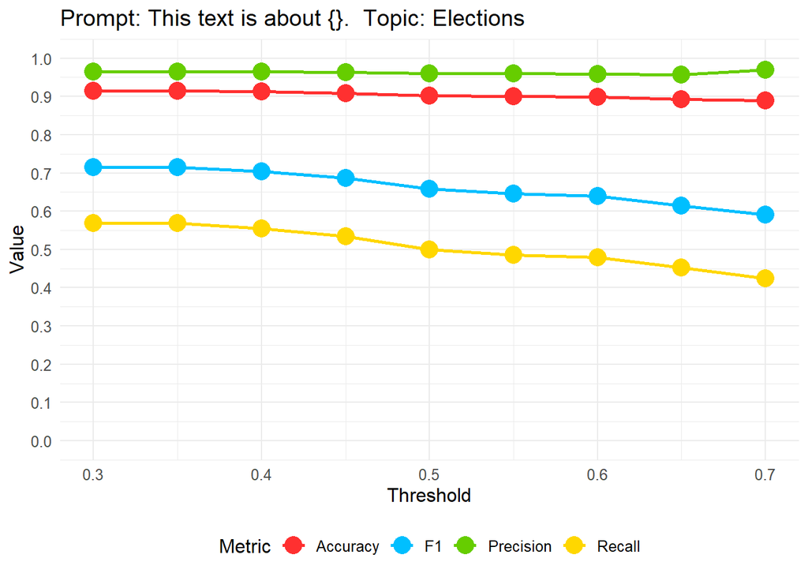

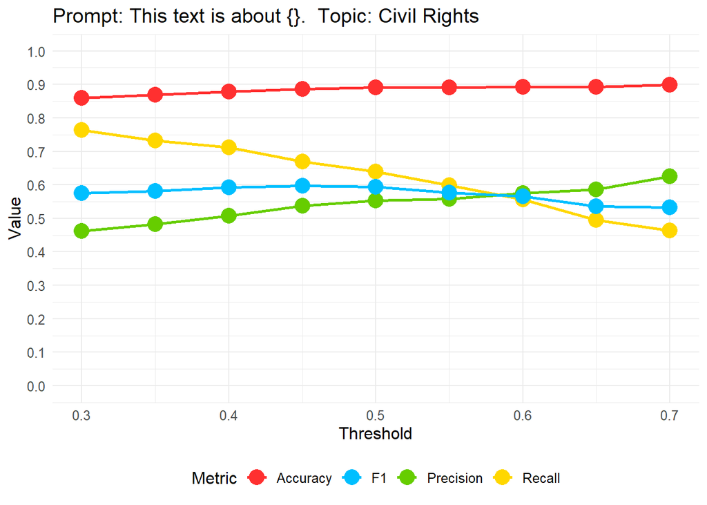

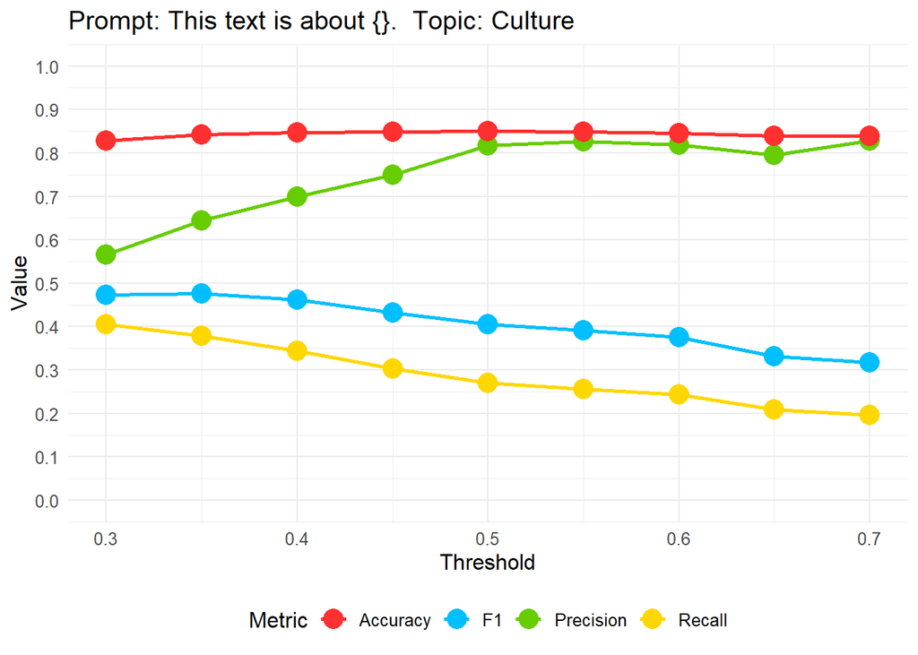

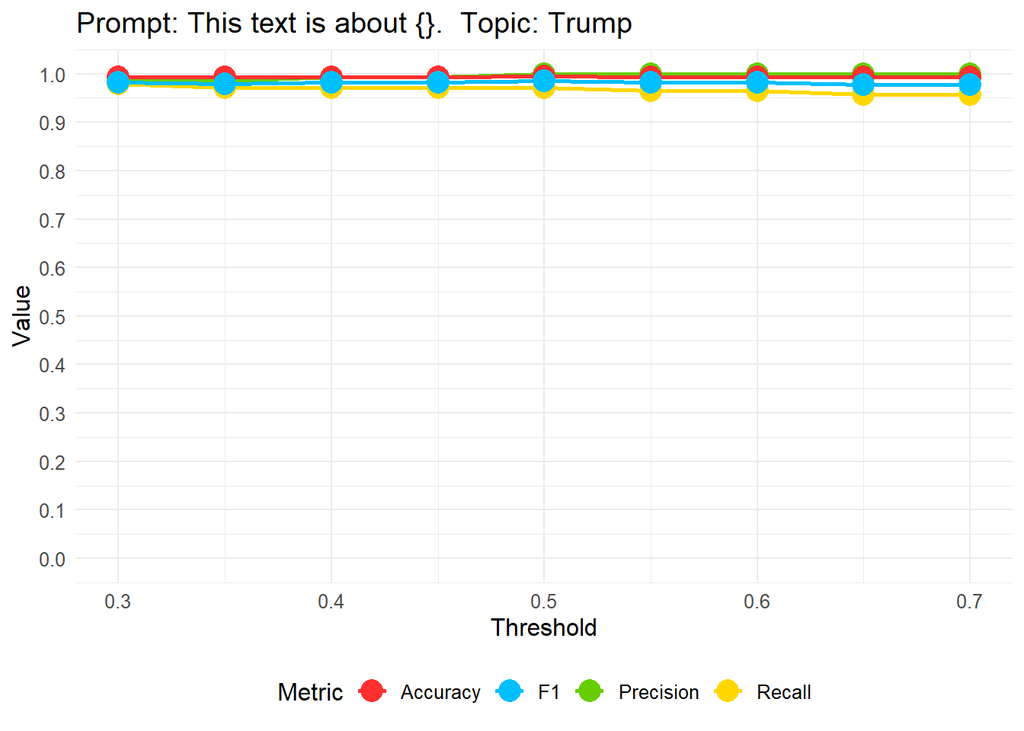

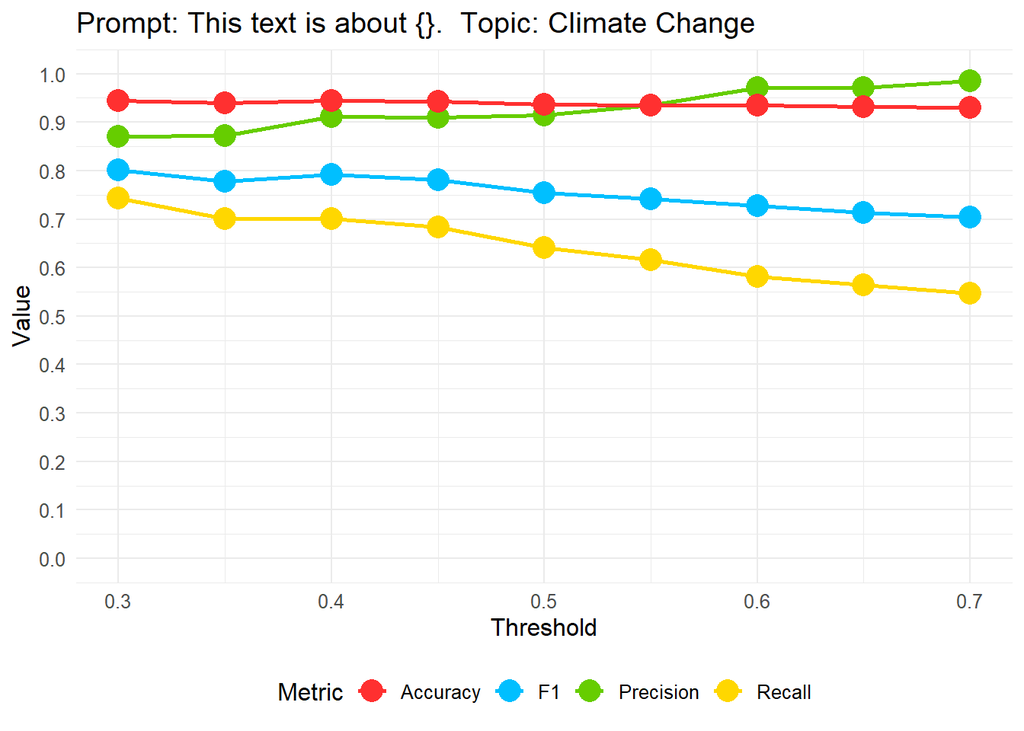

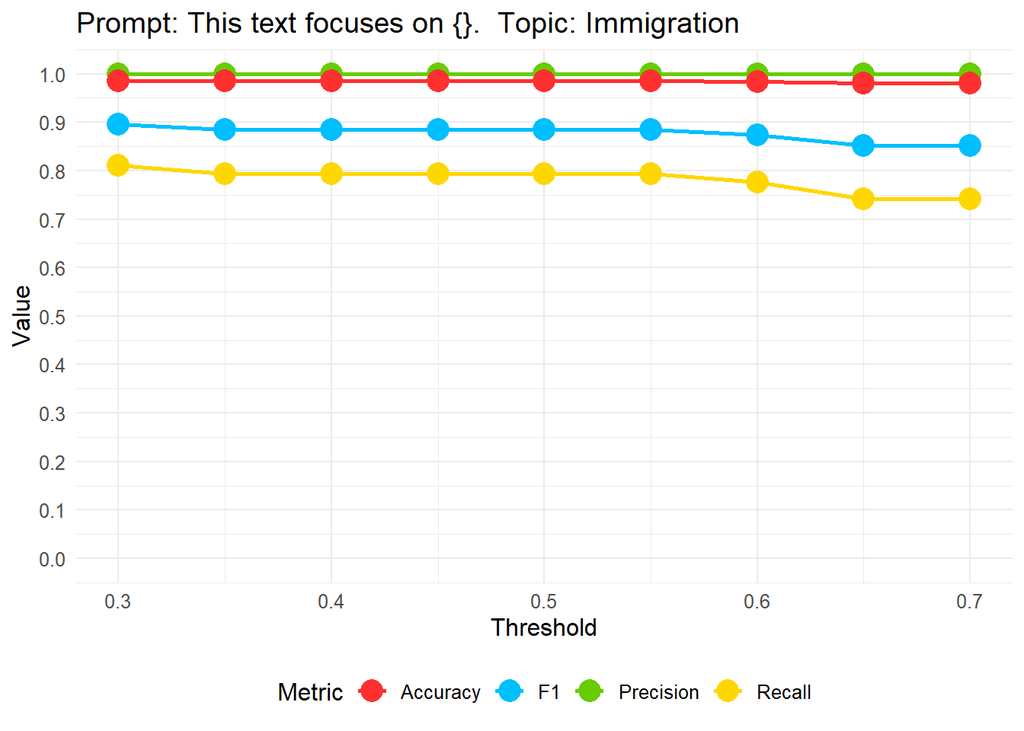

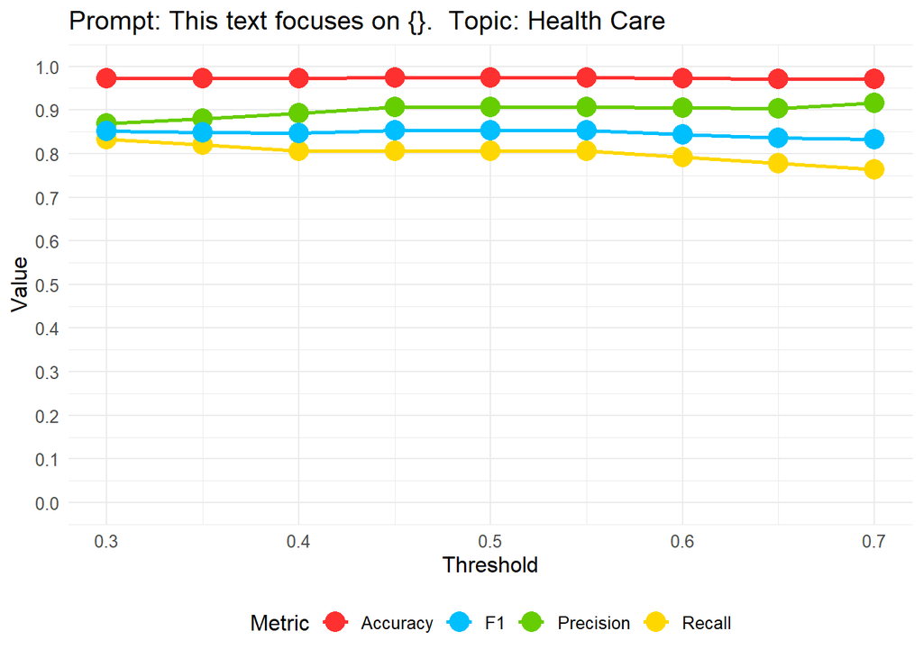

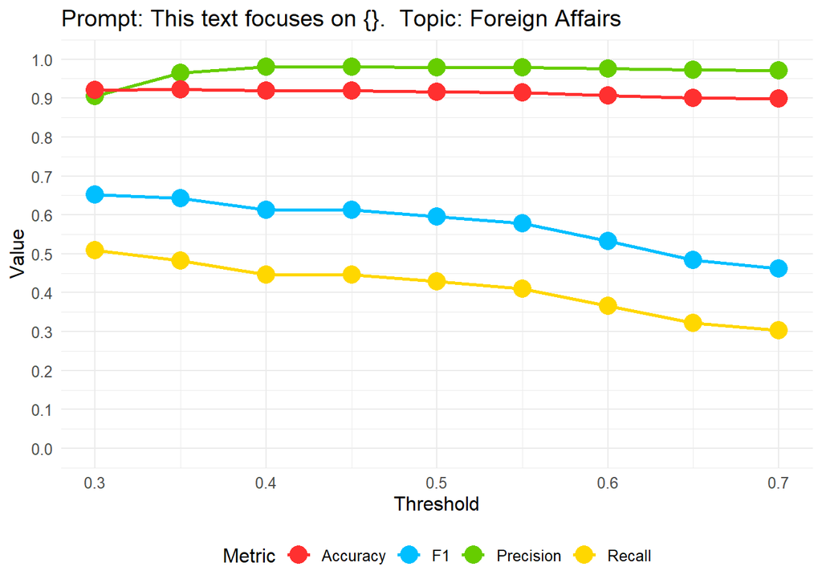

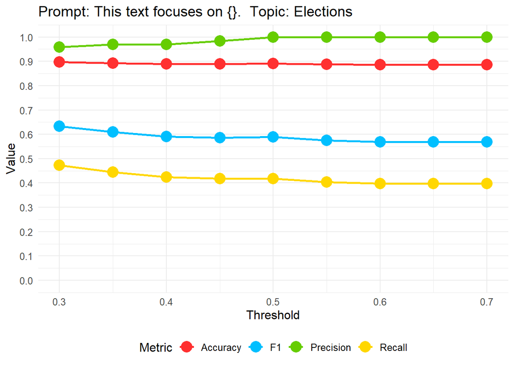

[20 more figures not shown]

```r
# Iterate over each unique combination of hypotheses and topics
for (i in 1:nrow(unique_combinations_LLM)) {
  hyp <- unique_combinations_LLM$hypothesis[i]
  top <- unique_combinations_LLM$topic[i]

  # Filter the data for the current combination
  subset <- results_pilot_LLM[results_pilot_LLM$hypothesis == hyp & results_pilot_LLM$topic == top, ]
  plot <- ggplot(subset, aes(x = TH)) +
    geom_line(aes(y = recall, color = "Recall"), linewidth =  1) +
    geom_point(aes(y = recall, color = "Recall"), size =  5) +
    geom_line(aes(y = precision, color = "Precision"), linewidth =  1) +
    geom_point(aes(y = precision, color = "Precision"), size =  5) +
    geom_line(aes(y = accuracy, color = "Accuracy"), linewidth =  1) +
    geom_point(aes(y = accuracy, color = "Accuracy"), size =  5) +
    geom_line(aes(y = f1, color = "F1"), linewidth =  1) +
    geom_point(aes(y = f1, color = "F1"), size =  5) +
    scale_color_manual(values = colors) +
    scale_y_continuous(limits=c(0,1),breaks=seq(0,1,by = 0.1))+
    labs(title = paste("Prompt:", hypothesis_LLM[as.numeric(unique_combinations_LLM$hyp[i])], " Topic:", labels_LLM[as.numeric(unique_combinations_LLM$top[i])]), x = "Threshold", y = "Value", color = "Metric") + theme_minimal() + theme(panel.background = element_rect(fill = "white", color = NA), legend.position = "bottom", text = element_text(size =  12))
  filename <- sprintf("Results/Pilot/LLM/Metrics Evolution/%s_%s_Evolution_of_Metrics.png", hyp, top)
  ggsave(filename = filename, plot = plot, dpi = 300, width = 10, height = 6, bg = "white")
  # Uncomment to plot
  print(plot)
}
```

#### Plot recall, accuracy, precision and f1 across the threshold for LLaMA

```r
# Obtain unique combinations of hypotheses and topics
unique_combinations_LLaMA <- unique(results_pilot_LLaMA[, c("hypothesis", "topic")])
labels_LLaMA= c("Immigration", "Health Care", "Foreign Affairs",'Elections',"Civil Rights","Culture","Trump","Climate Change")
hypothesis_LLaMA=c("This text is about {}.")
# Iterate over each unique combination of hypotheses and topics
colors_LLaMA <- c("Recall" = "#FFD700", "Precision" = "#66CD00", "Accuracy" = "#FF3030", "F1" = "#00BFFF", "Human Consensus-LLaMA 2 codes kappa"="#D15FEE", "Humans-LLaMA 3 codes kappa"="#FFC0CB", "Code 1-Code 2 kappa"="#C1CDC1", "Code 1-LLaMA kappa"="#8B0000", "Code 2-LLaMA kappa"="#27408B")
```

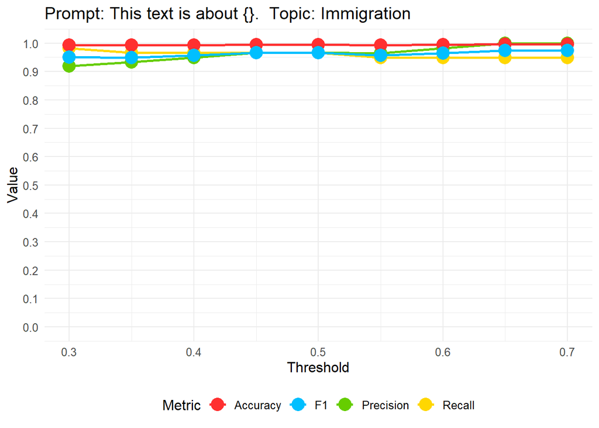

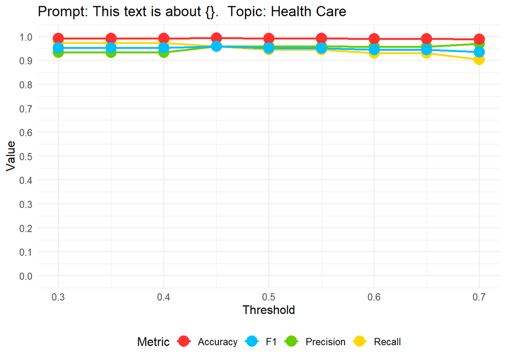

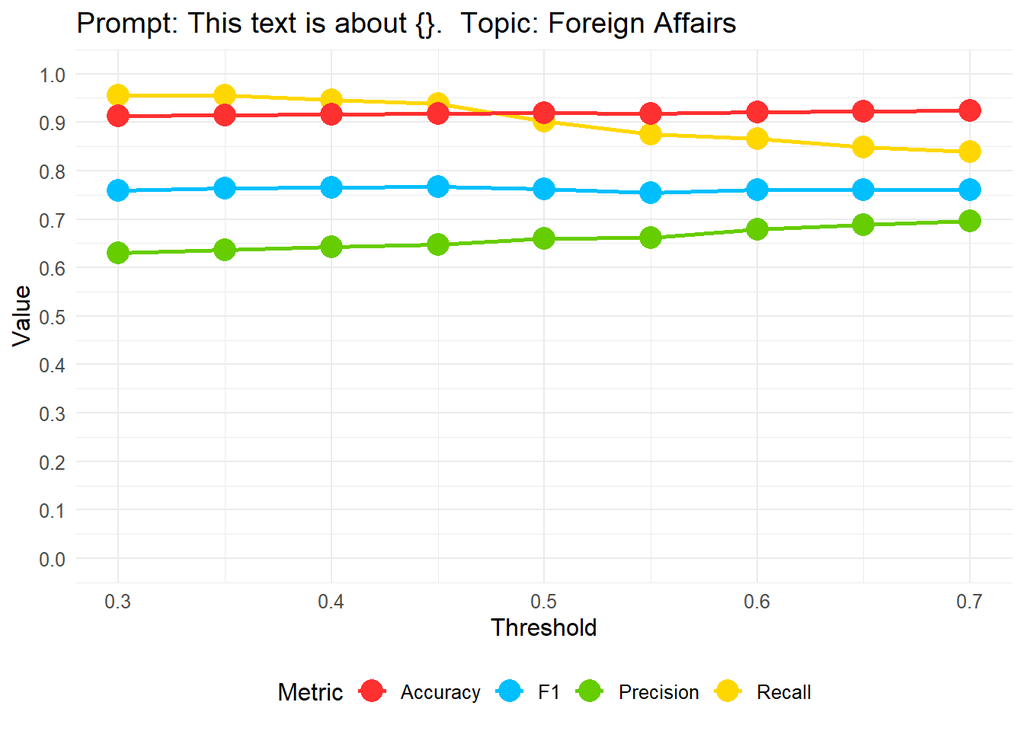

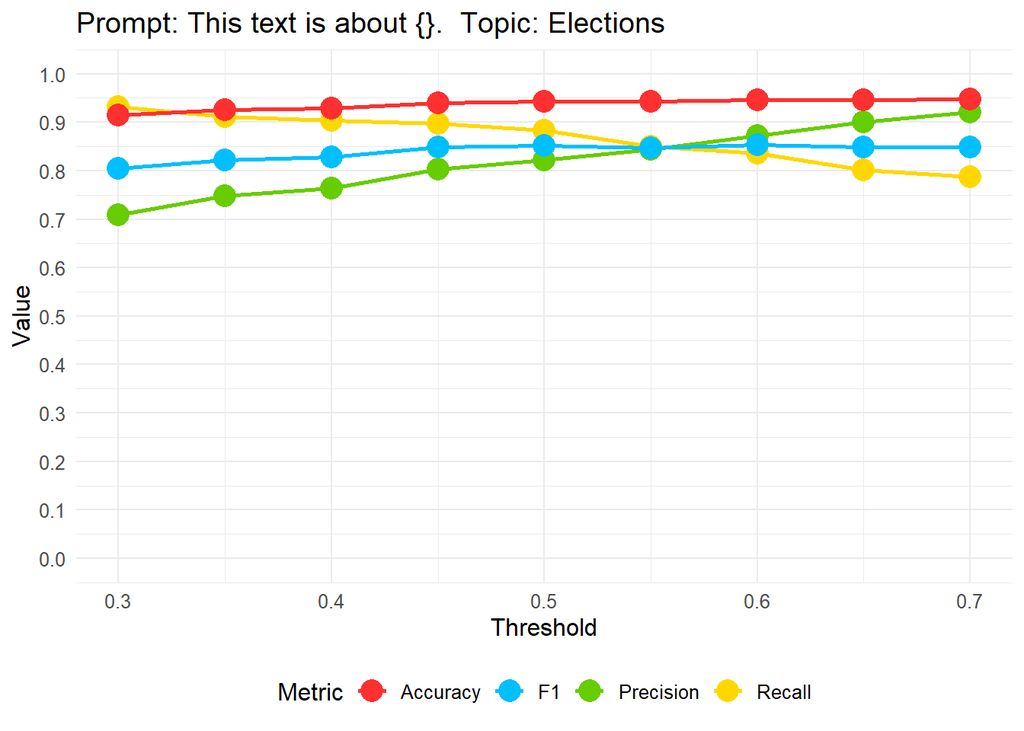

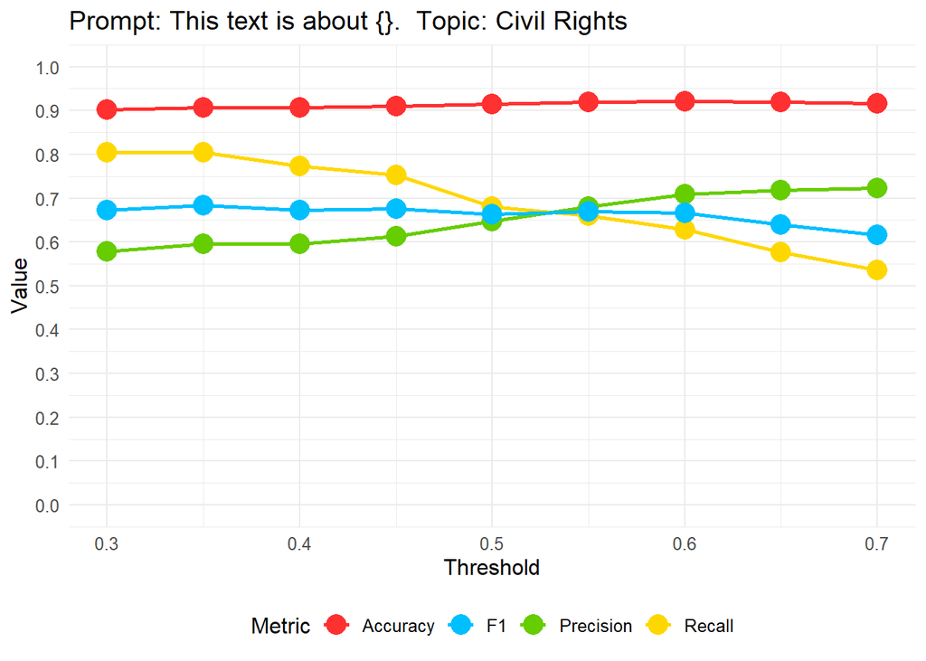

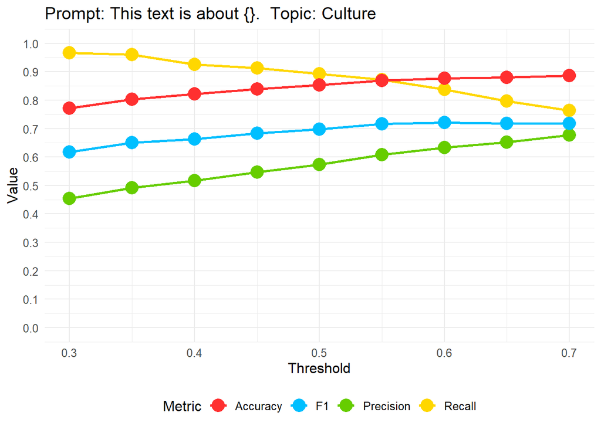

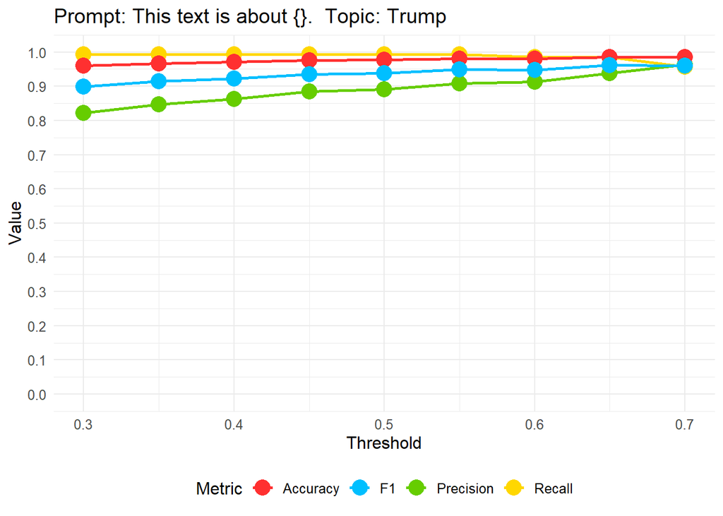

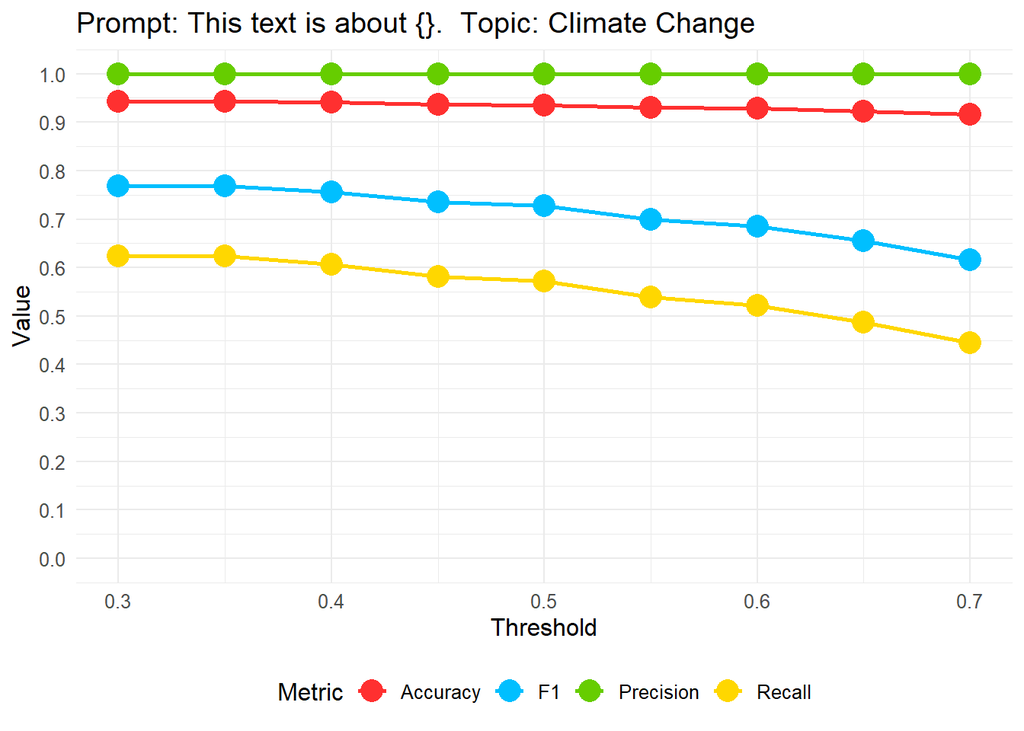

```r
for (i in 1:nrow(unique_combinations_LLaMA)) {
  hyp <- unique_combinations_LLaMA$hypothesis[i]
  top <- unique_combinations_LLaMA$topic[i]

  # Filter the data for the current combination
  subset <- results_pilot_LLaMA[results_pilot_LLaMA$hypothesis == hyp & results_pilot_LLaMA$topic == top, ]
  plot <- ggplot(subset, aes(x = TH)) +
    geom_line(aes(y = recall, color = "Recall"), linewidth =  1) +
    geom_point(aes(y = recall, color = "Recall"), size =  5) +
    geom_line(aes(y = precision, color = "Precision"), linewidth =  1) +
    geom_point(aes(y = precision, color = "Precision"), size =  5) +
    geom_line(aes(y = accuracy, color = "Accuracy"), linewidth =  1) +
    geom_point(aes(y = accuracy, color = "Accuracy"), size =  5) +
    geom_line(aes(y = f1, color = "F1"), linewidth =  1) +
    geom_point(aes(y = f1, color = "F1"), size =  5) +
    scale_color_manual(values = colors_LLaMA) +
    scale_y_continuous(limits=c(0,1),breaks=seq(0,1,by = 0.1))+
    labs(title = paste("Prompt:", hypothesis_LLaMA[as.numeric(unique_combinations_LLaMA$hyp[i])], " Topic:", labels_LLaMA[as.numeric(unique_combinations_LLaMA$top[i])]), x = "Threshold", y = "Value", color = "Metric") + theme_minimal() + theme(panel.background = element_rect(fill = "white", color = NA), legend.position = "bottom", text = element_text(size =  12))
  filename <- sprintf("Results/Pilot/LLaMA/Metrics Evolution/%s_%s_Evolution_of_Metrics.png", hyp, top)
  # Uncomment to save
  ggsave(filename = filename, plot = plot, dpi = 300, width = 10, height = 6, bg = "white")
  # Uncomment to plot
  print(plot)
}
```